# Eliciting Latent Knowledge

# ELK

Motivating example: AI-powered vault and the diamond (Christiano, Cotra, and Xu 2021)

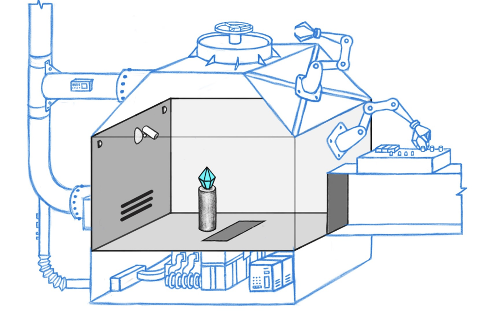

# How to define ELK

- ELK is the problem of
  - finding a training strategy which produces an AI agent such that
  - we can ask it questions about its latent variables
  - and it answers them in a robustly honest way

# Framework Used For This Project: Causal Bayesian Networks

Represent an agent’s model of the world via CBNs

# Issues

## Definitions

- What is a training strategy
- What does it mean for an agent with a CBN world model to give an *honest* response to a question

## Implementation

- **Goal misgeneralization**: Agents may internalise the correct causal structure of the world, but not the correct utility function
- **Ontology Mismatch** When and how can we ask agents with (potentially drastically) different world models questions and be understood by them in the right way

# First Pass at Honesty and Truthfulness

- Given $\mathcal{M}^O$, $\mathcal{M}^A$ and policy $\pi$ on $\mathcal{M}^O$; question about the value of node $C$. Say that, on question-answering decision $D$, $\pi$ is
  - *truthful* if
    $$\pi(D=c \mid \mathbf{Pa}^D) = 1$$
    iff
    $$c = \arg\!\max_{c \in dom(C)} Pr_{\mathcal{M}^O}^\pi(C=c \mid \mathbf{Pa}^D)$$
  - *honest* if
    $$\pi(D=c \mid \mathbf{Pa}^D) = 1$$
    iff
    $$c = \arg\!\max_{c \in dom(C)} Pr_{\mathcal{M}^A}^\pi(C=c \mid \mathbf{Pa}^D)$$

# Second Pass at Honesty and Truthfulness

- An agent $S$ **honestly** informs an agent $T$ about $\phi$ if $S$ intentionally causes $T$ to believe $\phi$ where $S$ believes $\phi$.
- An agent $S$ **truthfully** informs an agent $T$ about $\phi$ if $S$ intentionally causes $T$ to believe $\phi$ where $\phi$ is true.
- An agent $S$ **honestly**/**truthfully** reports their credence in $\phi$ to $T$ if $S$ **honestly**/**truthfully** informs $T$ about $Cr_{S}(\phi)=p$
- An agent $S$ **honestly**/**truthfully** reports on their **best guess for the value of variable** $C$ to $T$ if $S$ **honestly**/**truthfully** informs $T$ about the member of the set $\{c = \arg\!\max_{c \in dom(C)} Cr_S(C=c \mid \textbf{Pa}^D)\}$ which $S$ actually believes.
- An agent $A$ is capable in environment $O$ if $\mathcal{M}^A$ is equivalent to $\mathcal{M}^O$ up to the utility function.
- An agent is capably honest if the agent has adopted a honest policy and is capable
- For an environment $O$ containing a question for agent $A$ about formula $\phi$ at decision node $D$ say that $O$, say that the agent is **in a position to know $\phi$** at $D$ if $Pr_{\mathcal{M}^O}(\phi \mid \mathbf{Pa}^D)=1 \Leftrightarrow \phi$.
- *Theorem*: A capably honest agent who is in a position to know $\phi$ is truthful.

# References

Christiano, Paul, Ajeya Cotra, and Mark Xu. 2021. “Eliciting Latent Knowledge: How to Tell If Your Eyes Deceive You.” Alignment Research Center. https://docs.google.com/document/d/1WwsnJQstPq91_Yh-Ch2XRL8H_EpsnjrC1dwZXR37PC8.